# Using Machine Learning to Analyze Pokemon Card Price

## Spring 2025 Data Science Project

### Contributors: Annie Zhou, Evan Zhang, Hao Jiang, Ivy Lu, Jessie Gu, Raymond Chen

## Members Contribution Details

Contribution Details:

- A: Project Idea - 5%
- B: Dataset Curation and Preprocessing - 10%
- C: Data Exploration and Summary Statistic - 10%
- D: ML Algorithm Design/Development - 25%
- E: ML Algorithm Training and Test Data Analysis - 20%
- F: Visualization, Result Analysis, Conclusion - 15%
- G: Final Tutorial Report Creation - 10%
- H: Additional - 5%

Member 1: Annie Zhou; I, Annie Zhou, implemented the t-test for the third test as part of our data exploration (C). I also wrote the introduction section of the final tutorial report (G) and contributed to the results analysis and conclusion (F). Additionally, I attended all group meetings and actively participated in communication and collaboration throughout the project (H).

Member 2: Evan Zhang; I, Evan Zhang, helped to process our master dataframe prior to data exploration and applied meanwise imputation accounting for NaN values (B). I contributed to initial brainstorming for project ideas (A), as well as implementing/visualizing the ANOVA test as we explored the dataset (C). I helped implement Stratified K-Fold Cross Validation as we trained our ML model (E), and I attended all meetings/actively contributed in group settings.

Member 3: Hao Jiang; I, Hao Jiang, helped with the ML Algorithm Design/Development (D) section by proposing we train a KNN model based on our data. I helped to implement and increase the accuracy by tuning the hyperparameters of it (E). I also was an active communicator and attended meetings (H).

Member 4: Ivy Lu; I, Ivy Lu, contributed to the Data Exploration (C) part of this final project, implementing the t-test and the visualization of the third test. I also contributed to the final tutorial report creation (G) and added to the conlusion (F). I also attended all group meetings held and was an active communicator throughout the entirety of the project (H).

Member 5: Jessie Gu; I, Jessie Gu, helped to decide on the dataset used in the project (B). I also contributed to the preprocessing of the mastr dataframe and the correlation test of the second test (B) (C). I also wrote some sections od the final tutorial report (G) and the results analysis and conclusion (F). I also attended all meetings and was active in communication (H).

Member 6: Raymond Chen; I, Raymond Chen, contributed to the project idea and finding the proper dataset for the project. Additionally I also helped with the preprocessing of the master dataframe (A) (B). I also contributed to implementing/visualizing the correlation test for the second test (C). Additionally, I trimmed the data's outliers so that it was ready to be used for the machine learning model. As well as implementing and visualizing the model (E) (F).

## Introduction

In recent years, Pokémon cards have seen a dramatic resurgence in popularity, driven by both nostalgic collectors and new enthusiasts. This renewed interest has led to a sharp rise in the market value of many cards, especially those of higher rarities such as Illustration Rares, Special Rares, and Hyper Rares. While rarity is a property officially designated by the card's manufacturer, price is a dynamic, crowd-driven signal that reflects not only rarity, but also demand, aesthetic appeal, and more. Yet, with the explosion of card sales online–especially through platforms like eBay and TCGPlayer–price has arguably become one of the most visible indicators of a card’s perceived value.

This increase in market activity has raised important questions for collectors, investors, and researchers alike. Among them: Can the rarity of a Pokemon card be predicted based on its price?

In this project, we aim to investigate the relationship between a card’s price and its rarity designation–specifically, we build a predictive model that uses price data as input to estimate a card’s rarity class. By examining the predictive power of price, we hope to uncover broader insights into what drives value in the Pokemon card market and how closely rarity, a theoretically static attribute, aligns with real-world consumer behavior.

Understanding this relationship has practical implications. For buyers, such a model could help detect over- or under-priced cards based on their rarity, potentially helping them make more informed purchasing decisions. For sellers, it offers a way to benchmark pricing strategies against perceived rarity. And for researchers and hobbyists, it provides a data-driven lens through which to explore the intersection of gaming culture, economics, and predictive modeling.

## Data Collection

TCGCSV.com is a platform that compiles and updates daily CSV files containing pricing information for trading card games such as Pokémon. The dataset is structured into four levels: categories (e.g., Pokémon), groups (specific sets like SV01–SV09), products (individual cards with metadata like name, rarity, and set number), and market prices (including low, mid, and high prices). While TCGPlayer’s API doesn’t offer historical prices, TCGCSV archives daily price snapshots starting from February 8, 2024. This allows us to track trends over time if needed.

We are uploading all csv files of the Scarlet & Violet main and special sets.

Sets: SV01, SV02, SV03, SV: Scarlet & Violet 151, SV04, SV: Paldean Fates, SV05, SV06, SV: Shrouded Fable, SV07, SV08, SV: Prismatic Evolutions, SV09

```python
import pandas as pd
import scipy as sp
import numpy as np
import matplotlib.pyplot as plt
import scipy

sv01_df = pd.read_csv('SV01ScarletAndVioletBaseSetProductsAndPrices.csv')
sv02_df = pd.read_csv('SV02PaldeaEvolvedProductsAndPrices.csv')
sv03_df = pd.read_csv('SV03ObsidianFlamesProductsAndPrices.csv')
sv04_df = pd.read_csv('SV04ParadoxRiftProductsAndPrices.csv')
sv05_df = pd.read_csv('SV05TemporalForcesProductsAndPrices.csv')
sv06_df = pd.read_csv('SV06TwilightMasqueradeProductsAndPrices.csv')
sv07_df = pd.read_csv('SV07StellarCrownProductsAndPrices.csv')
sv08_df = pd.read_csv('SV08SurgingSparksProductsAndPrices.csv')
sv09_df = pd.read_csv('SV09JourneyTogetherProductsAndPrices.csv')
sv_151_df = pd.read_csv('SVScarletAndViolet151ProductsAndPrices.csv')
sv_pf_df = pd.read_csv('SVPaldeanFatesProductsAndPrices.csv')
sv_sf_df = pd.read_csv('SVShroudedFableProductsAndPrices.csv')
sv_pe_df = pd.read_csv('SVPrismaticEvolutionsProductsAndPrices.csv')
```

We then merge all of these sets into a master set, filter out unnecessary columns, and add a column for the textual set name based on groupId variable.

```python
master_df = pd.concat([sv01_df, sv02_df, sv03_df, sv04_df, sv05_df, sv06_df, sv07_df, sv08_df, sv09_df, sv_151_df, sv_pf_df, sv_sf_df, sv_pe_df])
master_df = master_df[['productId', 'name', 'groupId', 'lowPrice', 'highPrice', 'marketPrice', 'extRarity']]

# filter for cards of specific rarity
master_df = master_df[(master_df['extRarity'] == 'Special Illustration Rare') | (master_df['extRarity'] == 'Illustration Rare') | (master_df['extRarity'] == 'Hyper Rare')]

# add textual set name column
def get_textset(setId):
    setId_list = [22873, 23120, 23228, 23286, 23381, 23473, 23537, 23651, 24073, 23237, 23353, 23529, 23821]
    textId_list = [
        'Scarlet And Violet Base',
        'Paldea Evolved',
        'Obsidian Flames',
        'Paradox Rift',
        'Temporal Forces',
        'Twilight Masquerade',
        'Stellar Crown',
        'Surging Sparks',
        'Journey Together',
        'Scarlet And Violet 151',
        'Paldean Fates',
        'Shrouded Fable',
        'Prismatic Evolutions'
    ]
    index = setId_list.index(setId)
    return textId_list[index]

master_df['set'] = master_df['groupId'].apply(get_textset)

# add release date
def get_dateset(setId):
    name_list = ['Scarlet And Violet Base',
        'Paldea Evolved',
        'Obsidian Flames',
        'Paradox Rift',
        'Temporal Forces',
        'Twilight Masquerade',
        'Stellar Crown',
        'Surging Sparks',
        'Journey Together',
        'Scarlet And Violet 151',
        'Paldean Fates',
        'Shrouded Fable',
        'Prismatic Evolutions']
    date_list = [
        '05-31-2023',
        '06-09-2023',
        '08-11-2023',
        '10-03-2023',
        '03-22-2024',
        '05-24-2024',
        '09-13-2024',
        '11-08-2024',
        '03-28-2025',
        '09-22-2023',
        '01-26-2024',
        '09-02-2024',
        '01-17-2025'
    ]
    index = name_list.index(setId)
    return date_list[index]

master_df['set'] = master_df['groupId'].apply(get_textset)
master_df['release date'] = master_df['set'].apply(get_dateset)

# sort dataframe by card rarity
master_df = master_df.sort_values(by=['groupId', 'extRarity'])

# reset index
master_df = master_df.reset_index()
master_df.index +=1

master_df['release date'] = pd.to_datetime(master_df['release date'], format='%m-%d-%Y')

display(master_df)
```

|  | index | productId | name | groupId | lowPrice | highPrice | marketPrice | extRarity | set | release date |
| --- | --- | --- | --- | --- | --- | --- | --- | --- | --- | --- |
| 1 | 437 | 490043 | Miraidon ex - 253/198 | 22873 | 4.99 | 60.00 | 5.76 | Hyper Rare | Scarlet And Violet Base | 2023-05-31 |
| 2 | 439 | 490045 | Koraidon ex - 254/198 | 22873 | 3.00 | 28.20 | 5.50 | Hyper Rare | Scarlet And Violet Base | 2023-05-31 |
| 3 | 483 | 490294 | Basic Fighting Energy - 258/198 | 22873 | 2.39 | 25.00 | 3.14 | Hyper Rare | Scarlet And Violet Base | 2023-05-31 |
| 4 | 484 | 490295 | Basic Lightning Energy - 257/198 | 22873 | 3.00 | 50.00 | 5.01 | Hyper Rare | Scarlet And Violet Base | 2023-05-31 |
| 5 | 485 | 490296 | Rare Candy - 256/198 | 22873 | 5.80 | 30.02 | 7.83 | Hyper Rare | Scarlet And Violet Base | 2023-05-31 |
| ... | ... | ... | ... | ... | ... | ... | ... | ... | ... | ... |
| 437 | 338 | 623610 | Iono's Bellibolt ex - 183/159 | 24073 | 135.00 | 180.00 | 136.62 | Special Illustration Rare | Journey Together | 2025-03-28 |
| 438 | 339 | 623611 | Lillie's Clefairy ex - 184/159 | 24073 | 300.00 | 329.36 | 328.63 | Special Illustration Rare | Journey Together | 2025-03-28 |
| 439 | 340 | 623612 | N's Zoroark ex - 185/159 | 24073 | 214.10 | 219.99 | 219.62 | Special Illustration Rare | Journey Together | 2025-03-28 |
| 440 | 341 | 623613 | Hop's Zacian ex - 186/159 | 24073 | 175.00 | 179.99 | 178.79 | Special Illustration Rare | Journey Together | 2025-03-28 |
| 441 | 342 | 623614 | Salamence ex - 187/159 | 24073 | 200.00 | 240.00 | 238.03 | Special Illustration Rare | Journey Together | 2025-03-28 |

441 rows × 10 columns

We will also have to fill in all NaN values, especially for the market prices of recent sets (ie. SV09 Journey Together).

In order to fill in the NaN values, we will take the average of the lowPrice and highPrice values and input the average into marketPrice.

```python
def fill_market_price(row):
    if pd.isna(row['marketPrice']):
        low_high_average = (row['lowPrice'] + row['highPrice'])/2
        row['marketPrice'] = round(low_high_average, 2)
    return row['marketPrice']

master_df['marketPrice'] = master_df.apply(fill_market_price, axis=1)
```

## Exploratory Data Analysis

We will now conduct three hypothesis tests to observe trends and patterns in data. We used scipy for statistical tests and matplotlib and plotly for data visualization.

### TEST I: Test for mean card price per rarity across sets

Our first test determines if the mean price of cards across the same rarity vary significantly across all relevant sets (scarlet and violet main and special sets). Since we testing multiple categories and observing if they exist within the same distribution, an ANOVA test would be appropriate.

Significance level: $\alpha = 0.5$ (Level of confidence = 95%)

> $H_0$: There is no significant difference in the prices of the same card rarity across the relevant sets.

> $H_a$: There exists significant differences in the prices of the same card rarity across the relevant sets.

We first split up our master_df based on card rarity.

```python
hr_df = master_df[master_df['extRarity'] == 'Hyper Rare']
ir_df = master_df[master_df['extRarity'] == 'Illustration Rare']
sir_df = master_df[master_df['extRarity'] == 'Special Illustration Rare']
```

#### Hyper Rare Cards:

```python
# for Hyper Rare cards
hr_sets = hr_df.groupby('set', sort=False)
hr_average_prices = pd.DataFrame(columns=['set', 'averagePrice'])

for set,group in hr_sets:
    group = group.dropna(subset=['marketPrice']).sort_values(by='marketPrice')
    rarity_mean = group['marketPrice'].mean()
    row = {'set': set, 'averagePrice': round(rarity_mean, 2)}
    hr_average_prices = pd.concat([hr_average_prices, pd.DataFrame([row])], ignore_index=True)

hr_clean_avg = [group['marketPrice'].dropna().values for _, group in hr_df.groupby('set', sort=False)]

hr_res = sp.stats.f_oneway(*hr_clean_avg)
hr_tukey = sp.stats.tukey_hsd(*hr_clean_avg)

print(hr_res.pvalue)
print(hr_tukey)
```

```
1.2307944715509516e-06
Tukey's HSD Pairwise Group Comparisons (95.0% Confidence Interval)
Comparison  Statistic  p-value  Lower CI  Upper CI
 (0 - 1)      0.690     1.000   -31.715    33.095
 (0 - 2)     -3.223     1.000   -46.699    40.252
 (0 - 3)     -0.230     1.000   -43.705    43.245
 (0 - 4)     -0.245     1.000   -34.451    33.962
 (0 - 5)     -2.320     1.000   -37.818    33.178
 (0 - 6)     -6.393     1.000   -41.891    29.104
 (0 - 7)     -5.483     1.000   -40.981    30.014
 (0 - 8)    -25.485     0.479   -62.715    11.745
 (0 - 9)     -7.690     1.000   -51.165    35.785
 (0 - 10)    -20.675     0.718   -56.173    14.823
 (0 - 11)    -21.691     0.717   -58.921    15.539
 (0 - 12)    -85.747     0.000  -129.222   -42.271
 (1 - 0)     -0.690     1.000   -33.095    31.715
 (1 - 2)     -3.913     1.000   -44.902    37.076
 (1 - 3)     -0.920     1.000   -41.909    40.069
 (1 - 4)     -0.935     1.000   -31.920    30.050
 (1 - 5)     -3.010     1.000   -35.415    29.395
 (1 - 6)     -7.083     1.000   -39.488    25.321
 (1 - 7)     -6.173     1.000   -38.578    26.231
 (1 - 8)    -26.175     0.311   -60.469     8.119
 (1 - 9)     -8.380     1.000   -49.369    32.609
 (1 - 10)    -21.365     0.539   -53.770    11.040
 (1 - 11)    -22.381     0.554   -56.675    11.913
 (1 - 12)    -86.437     0.000  -127.426   -45.448
 (2 - 0)      3.223     1.000   -40.252    46.699
 (2 - 1)      3.913     1.000   -37.076    44.902
 (2 - 3)      2.993     1.000   -47.208    53.194
 (2 - 4)      2.979     1.000   -39.449    45.406
 (2 - 5)      0.903     1.000   -42.572    44.379
 (2 - 6)     -3.170     1.000   -46.645    40.305
 (2 - 7)     -2.260     1.000   -45.735    41.215
 (2 - 8)    -22.262     0.879   -67.163    22.639
 (2 - 9)     -4.467     1.000   -54.668    45.734
 (2 - 10)    -17.452     0.971   -60.927    26.024
 (2 - 11)    -18.468     0.966   -63.369    26.433
 (2 - 12)    -82.523     0.000  -132.724   -32.322
 (3 - 0)      0.230     1.000   -43.245    43.705
```

[output cut: 104 more lines]

```
 (11 - 9)     14.001     0.997   -30.900    58.903
 (11 - 10)      1.016     1.000   -36.214    38.246
 (11 - 12)    -64.055     0.001  -108.957   -19.154
 (12 - 0)     85.747     0.000    42.271   129.222
 (12 - 1)     86.437     0.000    45.448   127.426
 (12 - 2)     82.523     0.000    32.322   132.724
 (12 - 3)     85.517     0.000    35.316   135.718
 (12 - 4)     85.502     0.000    43.074   127.930
 (12 - 5)     83.427     0.000    39.951   126.902
 (12 - 6)     79.353     0.000    35.878   122.829
 (12 - 7)     80.263     0.000    36.788   123.739
 (12 - 8)     60.261     0.001    15.360   105.163
 (12 - 9)     78.057     0.000    27.856   128.258
 (12 - 10)     65.072     0.000    21.596   108.547
 (12 - 11)     64.055     0.001    19.154   108.957
```

#### Illustration Rare Cards

```python
# for Illustration Rare cards
ir_sets = ir_df.groupby('set', sort=False)
ir_average_prices = pd.DataFrame(columns=['set', 'averagePrice'])

for set,group in ir_sets:
    group = group.dropna(subset=['marketPrice']).sort_values(by='marketPrice')
    rarity_mean = group['marketPrice'].mean()
    row = {'set': set, 'averagePrice': round(rarity_mean, 2)}
    ir_average_prices = pd.concat([ir_average_prices, pd.DataFrame([row])], ignore_index=True)

ir_avg_prices = [group['marketPrice'].dropna().values for _, group in ir_df.groupby('set', sort=False)]

ir_res = sp.stats.f_oneway(*ir_avg_prices)
ir_tukey = sp.stats.tukey_hsd(*ir_avg_prices)

print(ir_res.pvalue)
print(ir_tukey)
```

```
0.030095002095402203
Tukey's HSD Pairwise Group Comparisons (95.0% Confidence Interval)
Comparison  Statistic  p-value  Lower CI  Upper CI
 (0 - 1)     -9.414     0.829   -26.916     8.089
 (0 - 2)      3.523     1.000   -19.959    27.004
 (0 - 3)    -14.061     0.575   -35.497     7.375
 (0 - 4)     -3.565     1.000   -21.272    14.142
 (0 - 5)     10.884     0.999   -29.788    51.556
 (0 - 6)     -1.691     1.000   -21.295    17.913
 (0 - 7)      0.258     1.000   -19.587    20.104
 (0 - 8)     -9.504     0.955   -31.364    12.357
 (0 - 9)     -2.183     1.000   -25.055    20.689
 (0 - 10)      3.248     1.000   -16.132    22.628
 (0 - 11)    -17.713     0.351   -41.194     5.769
 (1 - 0)      9.414     0.829    -8.089    26.916
 (1 - 2)     12.936     0.739    -9.203    35.075
 (1 - 3)     -4.648     1.000   -24.603    15.308
 (1 - 4)      5.848     0.987   -10.035    21.731
 (1 - 5)     20.298     0.875   -19.614    60.209
 (1 - 6)      7.722     0.959   -10.251    25.696
 (1 - 7)      9.672     0.841    -8.565    27.909
 (1 - 8)     -0.090     1.000   -20.501    20.321
 (1 - 9)      7.230     0.994   -14.260    28.721
 (1 - 10)     12.662     0.438    -5.068    30.391
 (1 - 11)     -8.299     0.985   -30.438    13.840
 (2 - 0)     -3.523     1.000   -27.004    19.959
 (2 - 1)    -12.936     0.739   -35.075     9.203
 (2 - 3)    -17.584     0.487   -42.947     7.780
 (2 - 4)     -7.088     0.996   -29.389    15.213
 (2 - 5)      7.362     1.000   -35.510    50.233
 (2 - 6)     -5.214     1.000   -29.049    18.621
 (2 - 7)     -3.264     1.000   -27.298    20.770
 (2 - 8)    -13.026     0.878   -38.749    12.697
 (2 - 9)     -5.706     1.000   -32.294    20.882
 (2 - 10)     -0.275     1.000   -23.926    23.377
 (2 - 11)    -21.235     0.293   -48.349     5.879
 (3 - 0)     14.061     0.575    -7.375    35.497
 (3 - 1)      4.648     1.000   -15.308    24.603
 (3 - 2)     17.584     0.487    -7.780    42.947
 (3 - 4)     10.496     0.856    -9.640    30.631
```

[output cut: 80 more lines]

```
 (10 - 7)     -2.989     1.000   -23.036    17.057
 (10 - 8)    -12.752     0.751   -34.794     9.291
 (10 - 9)     -5.431     1.000   -28.477    17.615
 (10 - 11)    -20.960     0.139   -44.612     2.691
 (11 - 0)     17.713     0.351    -5.769    41.194
 (11 - 1)      8.299     0.985   -13.840    30.438
 (11 - 2)     21.235     0.293    -5.879    48.349
 (11 - 3)      3.651     1.000   -21.712    29.015
 (11 - 4)     14.147     0.626    -8.154    36.448
 (11 - 5)     28.597     0.549   -14.275    71.468
 (11 - 6)     16.021     0.536    -7.814    39.856
 (11 - 7)     17.971     0.364    -6.063    42.005
 (11 - 8)      8.209     0.996   -17.514    33.932
 (11 - 9)     15.529     0.739   -11.059    42.117
 (11 - 10)     20.960     0.139    -2.691    44.612
```

#### Special Illustration Rare Cards

```python
# for Special Illustration Rare cards
sir_sets = sir_df.groupby('set', sort=False)
sir_average_prices = pd.DataFrame(columns=['set', 'averagePrice'])

for set,group in sir_sets:
    group = group.dropna(subset=['marketPrice']).sort_values(by='marketPrice')
    rarity_mean = group['marketPrice'].mean()
    row = {'set': set, 'averagePrice': round(rarity_mean, 2)}
    sir_average_prices = pd.concat([sir_average_prices, pd.DataFrame([row])], ignore_index=True)

sir_avg_prices = [group['marketPrice'].dropna().values for _, group in sir_df.groupby('set', sort=False)]

sir_res = sp.stats.f_oneway(*sir_avg_prices)
sir_tukey = sp.stats.tukey_hsd(*sir_avg_prices)

print(sir_res.pvalue)
print(sir_tukey)
```

```
0.0008935513093533929
Tukey's HSD Pairwise Group Comparisons (95.0% Confidence Interval)
Comparison  Statistic  p-value  Lower CI  Upper CI
 (0 - 1)     -2.927     1.000  -202.617   196.763
 (0 - 2)      1.641     1.000  -250.949   254.231
 (0 - 3)    -61.460     1.000  -302.510   179.589
 (0 - 4)     -7.115     1.000  -206.805   192.575
 (0 - 5)    -72.959     0.998  -304.977   159.059
 (0 - 6)    -30.827     1.000  -249.576   187.922
 (0 - 7)    -52.331     1.000  -266.051   161.389
 (0 - 8)    -14.055     1.000  -281.967   253.857
 (0 - 9)    -18.202     1.000  -270.792   234.387
 (0 - 10)    -81.494     0.986  -295.213   132.226
 (0 - 11)   -186.551     0.029  -363.758    -9.344
 (0 - 12)   -177.559     0.470  -430.149    75.031
 (1 - 0)      2.927     1.000  -196.763   202.617
 (1 - 2)      4.568     1.000  -231.708   240.844
 (1 - 3)    -58.533     1.000  -282.430   165.363
 (1 - 4)     -4.188     1.000  -182.796   174.420
 (1 - 5)    -70.032     0.996  -284.175   144.111
 (1 - 6)    -27.900     1.000  -227.590   171.790
 (1 - 7)    -49.404     1.000  -243.571   144.763
 (1 - 8)    -11.128     1.000  -263.718   241.462
 (1 - 9)    -15.275     1.000  -251.551   221.001
 (1 - 10)    -78.567     0.977  -272.734   115.601
 (1 - 11)   -183.624     0.006  -336.683   -30.565
 (1 - 12)   -174.632     0.387  -410.908    61.644
 (2 - 0)     -1.641     1.000  -254.231   250.949
 (2 - 1)     -4.568     1.000  -240.844   231.708
 (2 - 3)    -63.101     1.000  -335.233   209.030
 (2 - 4)     -8.756     1.000  -245.032   227.520
 (2 - 5)    -74.600     0.999  -338.765   189.565
 (2 - 6)    -32.468     1.000  -285.058   220.122
 (2 - 7)    -53.972     1.000  -302.219   194.275
 (2 - 8)    -15.696     1.000  -311.884   280.492
 (2 - 9)    -19.843     1.000  -302.247   262.561
 (2 - 10)    -83.135     0.996  -331.381   165.112
 (2 - 11)   -188.192     0.165  -405.799    29.415
 (2 - 12)   -179.200     0.634  -461.604   103.204
 (3 - 0)     61.460     1.000  -179.589   302.510
```

[output cut: 104 more lines]

```
 (11 - 9)    168.349     0.314   -49.258   385.955
 (11 - 10)    105.057     0.681   -65.903   276.017
 (11 - 12)      8.992     1.000  -208.615   226.599
 (12 - 0)    177.559     0.470   -75.031   430.149
 (12 - 1)    174.632     0.387   -61.644   410.908
 (12 - 2)    179.200     0.634  -103.204   461.604
 (12 - 3)    116.099     0.966  -156.033   388.230
 (12 - 4)    170.444     0.427   -65.832   406.720
 (12 - 5)    104.600     0.981  -159.565   368.765
 (12 - 6)    146.732     0.756  -105.858   399.322
 (12 - 7)    125.228     0.890  -123.019   373.475
 (12 - 8)    163.504     0.813  -132.684   459.692
 (12 - 9)    159.357     0.789  -123.047   441.761
 (12 - 10)     96.065     0.984  -152.181   344.312
 (12 - 11)     -8.992     1.000  -226.599   208.615
```

#### Graphs for ANOVA Tests:

- SVB - Scarlet And Violet Base
- PAL - Paldea Evolved
- PAR - Paradox Rift
- TEF - Temporal Forces
- TWM - Twilight Masquerade
- STC - Stellar Crown
- SSP - Surging Sparks
- JTG - Journey Together
- 151 - Scarlet And Violet 151
- PAF - Paldean Fates
- SHF - Shrouded Fable
- PRE - Prismatic Evolutions

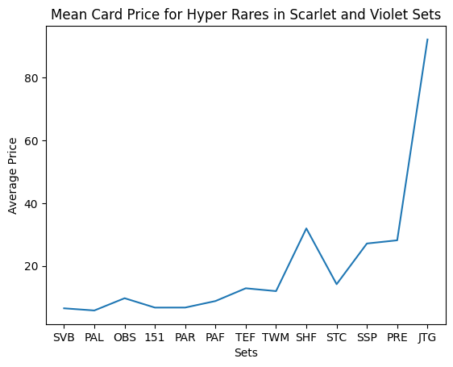

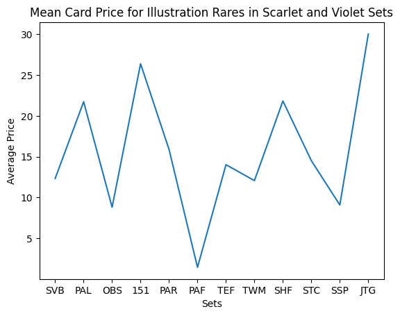

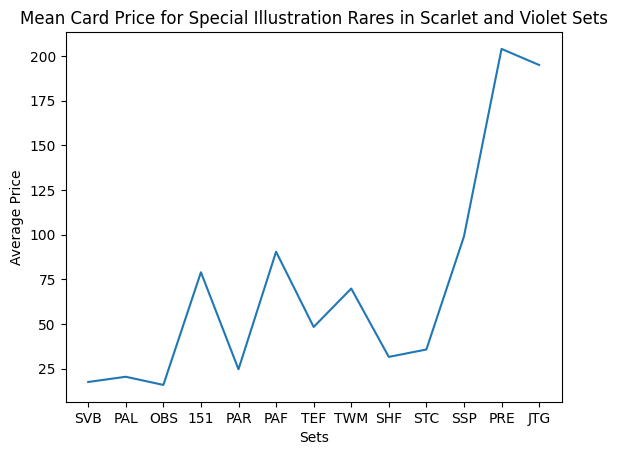

```python
set_list = ['SVB',
        'PAL',
        'OBS',
        '151',
        'PAR',
        'PAF',
        'TEF',
        'TWM',
        'SHF',
        'STC',
        'SSP',
        'PRE',
        'JTG']

ir_set_list = ['SVB',
        'PAL',
        'OBS',
        '151',
        'PAR',
        'PAF',
        'TEF',
        'TWM',
        'SHF',
        'STC',
        'SSP',
        'JTG']

# hyper rare cards graph
hr_avg_price_list = hr_average_prices['averagePrice'].values
plt.plot(set_list, hr_avg_price_list)
plt.title('Mean Card Price for Hyper Rares in Scarlet and Violet Sets')
plt.xlabel('Sets')
plt.ylabel('Average Price')

plt.show()

# illustration rare cards graph
ir_avg_price_list = ir_average_prices['averagePrice'].values
plt.plot(ir_set_list, ir_avg_price_list)
plt.title('Mean Card Price for Illustration Rares in Scarlet and Violet Sets')
plt.xlabel('Sets')
plt.ylabel('Average Price')

plt.show()

# special illustration rare cards graph
sir_avg_price_list = sir_average_prices['averagePrice'].values
plt.plot(set_list, sir_avg_price_list)
plt.title('Mean Card Price for Special Illustration Rares in Scarlet and Violet Sets')
plt.xlabel('Sets')
plt.ylabel('Average Price')

plt.show()
```

### ANOVA Test Results + Tukey Test Results Analysis

The p-value for the ANOVA test done on the average **hyper rare** market price across all sets is **1.2307944715509453e-06**, a number significantly smaller than 0.001 (<0.001). Because this p-value is significantly less than the given significance level of 0.05, we can conclude that there is a significant relationship between the card set and the average price of the hyper rares within the set.

*Analyzing the TUKEY test results, we can see that the hyper rares in SV09: Journey Together differ significantly than the hyper rares in any other set. This is the only observable significant difference within this dataset of hyper rare cards.*

The p-value for the ANOVA test done on the average **illustration rare** market price across all sets is **0.030095002095401828**. Because this p-value is significantly less than the given significance level of 0.05, we can conclude that there is a significant relationship between the card set and the average price of the illustration rares within the set.

*Analyzing the TUKEY test results, we can see that there are no significant differences between the hyper rares of any two sets. This observation suggests that the variation is spread across multiple sets rather than between specific pairs.*

- *note that SV: Prismatic Evolutions contains no illustration rares, therefore is not represented in this ANOVA and TUKEY test analysis*

The p-value for the ANOVA test done on the average **special illustration rare** market price across all sets is **0.0008935513093533942**. Because this p-value is significantly less than the given significance level of 0.05, we can conclude that there is a significant relationship between the card set and the average price of the special illustration rares within the set.

*Analyzing the TUKEY test results, we can see that there is a significant difference between the special illustration rares of SV: Prismatic Evolutions and SV01: Scarlet and Violet Base, SV: Prismatic Evolutions and SV02: Paldea Evolved, and SV: Prismatic Evolutions and SV05: Paradox Rift.*

### TEST II: Correlation Test between Popularity and Mean Price

Our second test, we will conduct a correlation test to determine whether or not the popularity of a set has an linear relation with the average price of a set. Since we are trying to two variables to see if they have a correlation with one another, a correlation test will be appropiate.

Significance level: $\alpha = 0.5$ (Level of confidence = 95%)

> $H_0$: There is no correlation between the average price of the set and the popularity of a set.

> $H_a$: There is a correlation between the average price of the set and the popularity of the set.

```python
sv01_price = sv01_df[sv01_df['name'] == 'Scarlet & Violet Booster Pack']
sv02_price = sv02_df[sv02_df['name'] == 'Paldea Evolved Booster Pack']
sv03_price = sv03_df[sv03_df['name'] == 'Obsidian Flames Booster Pack']
sv04_price = sv04_df[sv04_df['name'] == 'Paradox Rift Booster Pack']
sv05_price = sv05_df[sv05_df['name'] == 'Temporal Forces Booster Pack']
sv06_price = sv06_df[sv06_df['name'] == 'Twilight Masquerade Booster Pack']
sv07_price = sv07_df[sv07_df['name'] == 'Stellar Crown Booster Pack']
sv08_price = sv08_df[sv08_df['name'] == 'Surging Sparks Booster Pack']
sv09_price = sv09_df[sv09_df['name'] == 'Journey Together Booster Pack']
sv_151_price = sv_151_df[sv_151_df['name'] == '151 Booster Pack']
sv_pf_price = sv_pf_df[sv_pf_df['name'] == 'Paldean Fates Booster Pack']
sv_sf_price = sv_sf_df[sv_sf_df['name'] == 'Shrouded Fable Booster Pack']
sv_pe_price = sv_pe_df[sv_pe_df['name'] == 'Prismatic Evolutions Booster Pack']

prices = pd.concat([sv01_price, sv02_price, sv03_price, sv04_price, sv05_price, sv06_price, sv07_price, sv08_price, sv09_price, sv_151_price, sv_pf_price, sv_sf_price, sv_pe_price])

prices = prices[['marketPrice', 'groupId']]
prices['set'] = prices['groupId'].apply(get_textset)

def popularity_def(price):
    if price >= 10:
        return 1
    elif price >= 7:
        return 2
    elif price >= 6:
        return 3
    elif price >= 5:
        return 4
    else:
        return 5

prices['popularity'] = prices['marketPrice'].apply(popularity_def)
prices = prices.sort_values(by='set')

average_price = master_df.groupby('set', sort = 'name')['marketPrice'].mean()

sp.stats.pearsonr(average_price, prices['popularity'])
```

```
PearsonRResult(statistic=np.float64(-0.6902804971814794), pvalue=np.float64(0.009011909812729983))
```

### CORRELATION Test Result Analysis:

The correlation test results in a p-value of 0.009011909812729986. This p-value is significantly lower than 0.05, indicating that we have enough evidence to reject the null hypothesis. Therefore we will accept the alternative hypothesis instead, which states that there is a correlation between the average price and popularity of a set.

We determined the popularity of a set by ranking the prices of an individual booster pack for each set. For prices of over 10 dollars, we rank it with a popularity value of 1 (meaning its the most popular); for prices in between 7-10 dollars, it is ranked with a score of 2, 3 for 6-7 dollars, 4 for 5-6 dollars, and 5 for any booster packs priced under 5 dollars.

We paired each average price with a ranking, and the correlation test was performed with these pairs.

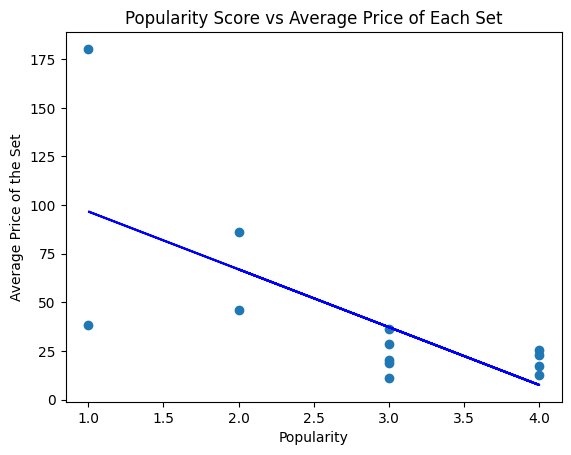

```python
x = prices['popularity']
y = average_price

plt.scatter(x,y)

plt.xlabel("Popularity")
plt.ylabel("Average Price of the Set")
plt.title("Popularity Score vs Average Price of Each Set")

m, b = np.polyfit(x,y, 1)

plt.plot(x, m*x + b, color='blue')

plt.show()
```

### TEST III: Pairwise T-Test between Volatility and Rarities

We will use pairwise T-tests to determine if there exists a significant difference between the volatility in prices between rarities. Here, we define volatility as the difference between a cards high and low price points.

Significance level: $\alpha = 0.5$ (Level of confidence = 95%)

> $H_0:$ There is no significant difference in the volatility in prices between rarities.

> $H_a:$ There is significant difference in the volatility in prices between rarities.

```python
from scipy.stats import ttest_ind

master_df['volatility'] = master_df['highPrice'].astype(float) - master_df['lowPrice'].astype(float)

ttest_hr_df = master_df[master_df['extRarity'] == 'Hyper Rare']
ttest_ir_df = master_df[master_df['extRarity'] == 'Illustration Rare']
ttest_sir_df = master_df[master_df['extRarity'] == 'Special Illustration Rare']

hr_vs_ir = ttest_ind(ttest_hr_df['volatility'], ttest_ir_df['volatility'])
hr_vs_sir = ttest_ind(ttest_hr_df['volatility'], ttest_sir_df['volatility'])
ir_vs_sir = ttest_ind(ttest_ir_df['volatility'], ttest_sir_df['volatility'])

print(f"The observed p-value of hyper rare cards versus illustration rare is: {hr_vs_ir[1]}")
print(f"The observed p-value of hyper rare cards versus special illustration rare is: {hr_vs_sir[1]}")
print(f"The observed p-value of illustration rare cards versus special illustration rare is: {ir_vs_sir[1]}")
```

```
The observed p-value of hyper rare cards versus illustration rare is: 0.32509098167592854
The observed p-value of hyper rare cards versus special illustration rare is: 0.08174837546624164
The observed p-value of illustration rare cards versus special illustration rare is: 0.5146676677454878
```

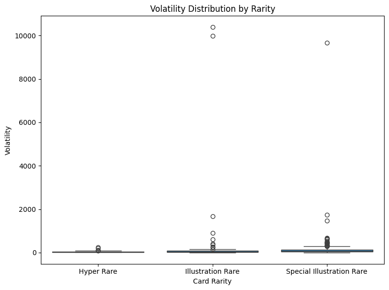

```python
import seaborn as sns

plt.figure(figsize=(8,6))
sns.boxplot(data=master_df, x='extRarity', y='volatility')
plt.title('Volatility Distribution by Rarity')
plt.ylabel('Volatility')
plt.xlabel('Card Rarity')
plt.tight_layout()
plt.show()
```

## Primary Analysis

```python
hyper_rare = master_df[master_df['extRarity'] == 'Hyper Rare']
ir = master_df[master_df['extRarity'] == 'Illustration Rare']
sir = master_df[master_df['extRarity'] == 'Special Illustration Rare']

col = "marketPrice"

rare_lower_pct = hyper_rare[col].quantile(0.1)
rare_upper_pct = hyper_rare[col].quantile(0.9)

ir_lower_pct = ir[col].quantile(0.1)
ir_upper_pct = ir[col].quantile(0.9)

sir_lower_pct = sir[col].quantile(0.1)
sir_upper_pct = sir[col].quantile(0.9)

rare_pct = hyper_rare[(hyper_rare[col] >= rare_lower_pct) & (hyper_rare[col] <= rare_upper_pct)]
ir_pct = ir[(ir[col] >= ir_lower_pct) & (ir[col] <= ir_upper_pct)]
sir_pct = sir[(sir[col] >= sir_lower_pct) & (sir[col] <= sir_upper_pct)]
```

```python
from sklearn.preprocessing import LabelEncoder, StandardScaler
from sklearn.neighbors import KNeighborsClassifier
from sklearn.model_selection import cross_val_predict, StratifiedKFold
from sklearn.metrics import classification_report, confusion_matrix, accuracy_score
from sklearn.pipeline import make_pipeline
import matplotlib.pyplot as plt
from sklearn.model_selection import train_test_split

model_df = pd.concat([rare_pct, ir_pct, sir_pct], ignore_index=True)

X = model_df[['marketPrice']].values
y = model_df['extRarity'].values

le = LabelEncoder()
y_encoded = le.fit_transform(y)

knn_pipeline = make_pipeline(
    StandardScaler(),
    KNeighborsClassifier(n_neighbors=9)
)

skf = StratifiedKFold(n_splits=5, shuffle=True, random_state=42)

y_pred = cross_val_predict(knn_pipeline, X, y_encoded, cv=skf, n_jobs=-1)


print(f"Stratified K-Fold Accuracy: {accuracy_score(y_encoded, y_pred):.2%}\n")
print("Classification Report:")
print(classification_report(y_encoded, y_pred, target_names=le.classes_))
print("Confusion Matrix:")
print(confusion_matrix(y_encoded, y_pred))
```

```
Stratified K-Fold Accuracy: 70.94%

Classification Report:
                           precision    recall  f1-score   support

               Hyper Rare       0.42      0.09      0.15        54
        Illustration Rare       0.67      0.90      0.77       185
Special Illustration Rare       0.86      0.69      0.76       112

                 accuracy                           0.71       351
                macro avg       0.65      0.56      0.56       351
             weighted avg       0.69      0.71      0.67       351

Confusion Matrix:
[[  5  47   2]
 [  7 167  11]
 [  0  35  77]]
```

## Visualization

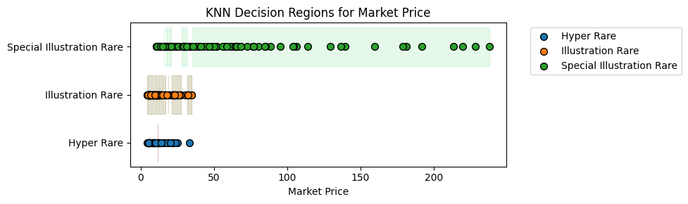

```python
from matplotlib.colors import to_rgba

scaler = StandardScaler()
X_scaled = scaler.fit_transform(X)
knn = KNeighborsClassifier(n_neighbors=9)
knn.fit(X_scaled, y_encoded)

price_grid = np.linspace(X.min(), X.max(), 500).reshape(-1, 1)
price_grid_scaled = scaler.transform(price_grid)
grid_preds = knn.predict(price_grid_scaled)

plt.figure(figsize=(10, 3))

class_colors = {
    0: to_rgba("#91574e", 0.3),
    1: to_rgba("#9e9660", 0.3),
    2: to_rgba("#a9e8ba", 0.3)}


for cls in np.unique(grid_preds):
    mask = (grid_preds == cls)
    plt.fill_between(
        price_grid.ravel(),
        cls - 0.4,
        cls + 0.4,
        where=mask,
        color=class_colors[cls],
        alpha=0.3)

for cls in np.unique(y_encoded):
    mask = (y_encoded == cls)
    plt.scatter(
        X[mask].ravel(),
        np.full(mask.sum(), cls),
        label=le.inverse_transform([cls])[0],
        edgecolor='k',
        s=50)

plt.yticks(sorted(np.unique(y_encoded)), le.classes_)
plt.ylim(-0.5, len(le.classes_) - 0.5)
plt.xlabel("Market Price")
plt.title("KNN Decision Regions for Market Price")
plt.legend(bbox_to_anchor=(1.05, 1), loc="upper left")
plt.tight_layout()
plt.show()
```

## Insights and Conclusions

In this project, we conducted a comprehensive analysis of Pokémon card prices from the Scarlet & Violet series using both statistical methods and machine learning. Our exploration revealed several key insights into how card prices vary by rarity and set, and how those prices can relate to a card's popularity and market volatility.

First, our ANOVA and Tukey post-hoc tests showed statistically significant differences in card prices across sets for all three rarities. Particularly for Hyper Rare and Special Illustration Rare cards, specific sets stood out with significantly higher prices, suggesting that certain sets may drive collector and reseller interest more than others.

Our volatility analysis found no significant difference in price fluctuations across rarities, suggesting that while absolute prices vary, the degree of fluctuation in prices is relatively stable across rarities. This could indicate a consistent level of market speculation or trading activity across card tiers.

Most directly addressing our central research question, we trained a K-Nearest Neighbors (KNN) classifier to predict a card’s rarity based on its price. Our model achieved an accuracy of over 70%, demonstrating that price alone is a moderately strong predictor of rarity. However, the model struggled with rarer categories, emphasizing the limitations of using a single numerical feature. This insight motivates the need to explore multi-feature models, possibly incorporating metadata such as card artwork type, set popularity, print volume, or historical pricing trends for better classification performance.

After reading through this project, an uninformed reader would have seen all the steps taken in setting up a ML model for a specific dataset and gained some insight into why we chose specific tests/ML models. This project demostrates some of the steps involved in the Data Science lifecycle which would be informative to someone who is uninformed about data science.

Ultimately, our analysis shows that while price can be used to predict rarity with reasonable accuracy, it also reflects a complex interplay of other factors like demand, set prestige, and collector behavior. By combining statistical inference with machine learning, this project highlights the potential of data science to uncover hidden patterns in niche markets and offers a framework for applying predictive modeling to other collectible or crowd-valued domains. For both casual collectors and informed researchers, our findings provide a meaningful look at the real-world dynamics behind perceived value and how static designations like rarity interact with a fluid, consumer-driven market. This work illustrates key steps in the data science lifecycle, from data management to model development, and serves as an accessible case study in applying machine learning to cultural and economic phenomena.